# Time Lagged Analysis in R

Jacob Cram

The point of this lesson is to show that you can do a time lagged network in R, no LSA program required. This skips the “local” element of Local Similarity Analysis, but I found that in my research I was electing just to do time lagged spearman networks. Similarly, one could use this same approach to build a time lagged sparCC network or most other statistics.

This may or may not work for graphical lasso approaches.

```r
library(tidyverse)
library(lubridate)
library(zoo)
library(SpiecEasi)
library(psych)
library(igraph)
```

# Read in

Lets bring in some time-series data from the SPOT dataset. These are ARISA fragements, their lengths associate with species identity. I downloaded the data here:

https://www.bco-dmo.org/dataset/535915

And then removed some variables that we are not using yet.

The data set is somewhat large. To save space, I’ve zipped it.

```r
# read in data
spotSurface <- read_csv("SPOT/spot_arisa_surface.zip") %>%
  # treat date column as a date, rather than a character string
  mutate(date_local = ymd(date_local))
```

# Removing low occurance taxa

```r
howMany <- spotSurface %>%
  group_by(arisa_frag) %>%
  summarize(sightings = sum(na.omit(rel_abund > 0)),
            meanAbun = mean(na.omit(rel_abund))) %>%
  arrange(-sightings)


keepTaxa <- howMany %>%
  filter(sightings >= 5, meanAbun >= 0.01) %>%
  pull(arisa_frag)

keepTaxa
```

```
 [1] "ARISA_670.5" "ARISA_538.9" "ARISA_666.4" "ARISA_662"   "ARISA_686.9" "ARISA_435.5" "ARISA_682.4" "ARISA_419.5" "ARISA_676.9" "ARISA_421.5" "ARISA_689.8" "ARISA_729.4" "ARISA_570.1"
[14] "ARISA_667.6" "ARISA_573.6" "ARISA_679.4" "ARISA_561.8" "ARISA_402.4" "ARISA_828.8" "ARISA_831.8" "ARISA_594.1"
```

```r
spotSurface2 <- spotSurface %>% filter(arisa_frag %in% keepTaxa)
```

# Processing

Lets reshape everything into a wide format data frame

```r
spotWide <- spotSurface2 %>% pivot_wider(names_from = arisa_frag, values_from = rel_abund)
```

There are lots of months with missing data, and lots of months that are missing but don’t have rows. Lets update this so that we have a row for every month, even if it has NA values.

```r
spotWide2 <- spotWide %>%
  na.omit %>%
  mutate(yr = year(date_local), mth = month(date_local)) %>%
  select(yr, mth, date_local, everything()) %>%
  arrange(yr, mth)
```

```r
goalDates <- tibble(
  yr = rep(first(spotWide2$yr):last(spotWide2$yr), each = 12),
  mth = rep(1:12, last(spotWide2$yr) - first(spotWide2$yr) + 1)
) %>%
  mutate(filler_date = ymd(paste(yr, mth, 15, sep = "_"))) %>%
  filter(filler_date > min(spotWide2$date_local) &
           filler_date < max(spotWide2$date_local)) %>%
  select(-filler_date)
```

```r
spotWideAllMonths <- left_join(goalDates, spotWide2)
```

Ok. So we’re going to address this missing not at random data in a way that critics might call reckless. Linearly interpolating it.

```r
spotInterp <- spotWideAllMonths %>%
  mutate_at(vars(matches("ARISA")), na.approx)
```

```r
spotInterp2 <- spotInterp %>%
  mutate(date_local = if_else(
    is.na(date_local),
    ymd(paste(yr, mth, 15)),
    date_local)
  ) %>%
  select(-c(yr, mth))
```

```r
spotInterpMtx <- spotInterp2 %>%
  column_to_rownames("date_local") %>%
  as.matrix()

spotClrMtx <- clr(spotInterpMtx)
```

# Saving out for eLSA

For the lesson on eLSA, we need formatted data that we will export here. eLSA wants comma seperated values. It also wants a `#` sign in the upper left hand cell. Also, its particular about special characters in column names.

```r
# Write the matrix to csv. You can't use tidyverse's write_csv, which expects data frames (unless you first translated to data frame)
cat("#, ", file = "SPOT/spotClrMtx.csv")
thout <- write.table(spotClrMtx, "SPOT/spotClrMtx.tsv", quote = FALSE, sep = "\t", append = TRUE)
```

```
appending column names to file
```

```r
# Then add a pound sign to the file
```

# Lags

Ok, so with this dataset, we can do any of the things from the earlier lessons. We can also export it for local similarity analysis outside of R.

Ok, lets make a new matrix, where the columns are dates, but then there are another series of columns of dates lagged by one.

```r
spotUnLag <- spotInterpMtx[-1,]
spotLag <- spotInterpMtx[-nrow(spotInterpMtx),]
colnames(spotUnLag) <- paste("nolag", colnames(spotUnLag), sep = "-")
colnames(spotLag) <- paste("lag1", colnames(spotLag), sep = "-")
spotWLag <- cbind(spotUnLag, spotLag)
```

Now we’ll correlate everything vs everyting. Keep in mind that the unlagged vs unlagged are missing one row. We could get around this by doing everything in two batches.

# Calculating clr-spearman matrix

## Non lagged data

```r
spearCorTestClr <- corr.test(spotInterpMtx, method = "spearman", adjust = "none")
spearCorClr <- spearCorTestClr$r
spearPClr <- spearCorTestClr$p
```

## Lagged data

```r
spearCorTestClr_Lagged <- corr.test(spotWLag, method = "spearman", adjust = "none")
spearCorClr_Lagged <- spearCorTestClr_Lagged$r
spearPClr_Lagged <- spearCorTestClr_Lagged$p
```

```r
source("jacob_library.R")
```

Some data wrangling, as per my earlier lesson

```r
reordered_spearCorTestClr_Lagged <- reorder_cor_and_p(spearCorClr_Lagged, spearPClr_Lagged)
spearCorClr_Lagged_Reordered <- reordered_spearCorTestClr_Lagged$r
spearPClr_Lagged_Reordered <- reordered_spearCorTestClr_Lagged$p
```

```r
spearCorClr_Lagged_Proc <- spearCorClr_Lagged_Reordered %>% get_upper_tri() %>% reshape2::melt() %>% na.omit() %>% rename(rho = value)
spearPClr_Lagged_Proc <- spearPClr_Lagged_Reordered %>% get_upper_tri() %>% reshape2::melt() %>% na.omit() %>% rename(p = value)
```

```r
spearRhoP_lagged <- left_join(spearCorClr_Lagged_Proc, spearPClr_Lagged_Proc, by = c("Var1", "Var2"))
spearRhoP_lagged
```

| Var1 | Var2 | rho | p |
| --- | --- | --- | --- |
| nolag-ARISA_538.9 | nolag-ARISA_538.9 | 1.0000000000 | 0.000000e+00 |
| nolag-ARISA_538.9 | lag1-ARISA_538.9 | 0.3680331611 | 4.128441e-05 |
| lag1-ARISA_538.9 | lag1-ARISA_538.9 | 1.0000000000 | 0.000000e+00 |
| nolag-ARISA_538.9 | nolag-ARISA_666.4 | 0.2808851914 | 2.063145e-03 |
| lag1-ARISA_538.9 | nolag-ARISA_666.4 | 0.1414304836 | 1.265961e-01 |
| nolag-ARISA_666.4 | nolag-ARISA_666.4 | 1.0000000000 | 0.000000e+00 |
| nolag-ARISA_538.9 | nolag-ARISA_686.9 | 0.4153652872 | 2.909801e-06 |
| lag1-ARISA_538.9 | nolag-ARISA_686.9 | 0.2291864491 | 1.254531e-02 |
| nolag-ARISA_666.4 | nolag-ARISA_686.9 | 0.6144930766 | 1.350057e-13 |
| nolag-ARISA_686.9 | nolag-ARISA_686.9 | 1.0000000000 | 0.000000e+00 |

[output cut: 893 more lines]

## Parsing out the lags

```r
wrangle_lagged <- function(preWrangled, coef = "rho"){ # I need to allow the coefficient name to change for the sparcc stuff
  # Initial wrangling
  postWrangled <- preWrangled %>%
  separate(Var1, c("V1", "Var1"), sep = "-") %>%
  separate(Var2, c("V2", "Var2"), sep = "-") %>%
  # get rid of rows where both variables are laged
  filter(!(V1 == "lag1" & V2 == "lag1")) %>%
  filter(Var1 != Var2) %>%
  mutate(delay = if_else(V1 == "lag1" & V2 == "nolag", -1,
         if_else(V1 == "nolag" & V2 == "lag1", 1,
                 if_else(V1 == "nolag" & V2 == "nolag", 0, -9999)
         )
  )
  ) %>%
  mutate(fdr =p.adjust(p, method = "BH"))

# Now we select the delay with the highest score.
#
# Note that we calculated the false discovery rate *before* we selected the value with the highest score, but *after* we removed the delay-vs-delay comparasons.

  bestLag <- postWrangled %>%
  group_by(Var1, Var2) %>%
  top_n(1, !!as.name(coef)) %>%
  select(-c(V1, V2))


  ## Add arrows for easier igraph plotting

  arrowedData <- bestLag %>%
  #filter(fdr < 0.05) %>%
  mutate(arrow = recode(delay, `-1` = "<", `1` = ">", `0` = "-"))

  arrowedData
}


spearRhoP_lagged4<- spearRhoP_lagged %>% wrangle_lagged
```

```r
# spearRhoP_lagged2 <- spearRhoP_lagged %>%
#   separate(Var1, c("V1", "Var1"), sep = "-") %>%
#   separate(Var2, c("V2", "Var2"), sep = "-") %>%
#   # get rid of rows where both variables are laged
#   filter(!(V1 == "lag1" & V2 == "lag1")) %>%
#   filter(Var1 != Var2) %>%
#   mutate(delay = if_else(V1 == "lag1" & V2 == "nolag", -1,
#          if_else(V1 == "nolag" & V2 == "lag1", 1,
#                  if_else(V1 == "nolag" & V2 == "nolag", 0, -9999)
#          )
#   )
#   ) %>%
#   mutate(fdr =p.adjust(p, method = "BH"))
#
# spearRhoP_lagged2
```

Now we select the delay with the highest score.

Note that we calculated the false discovery rate *before* we selected the value with the highest score, but *after* we removed the delay-vs-delay comparasons.

```r
# spearRhoP_lagged3 <- spearRhoP_lagged2 %>%
#   group_by(Var1, Var2) %>%
#   top_n(1, rho) %>%
#   select(-c(V1, V2))
# spearRhoP_lagged3
```

And there you have a table that can go into a network. Some thoughts. There is way more data handling to do this with sparcc, but it could be done. I really ought to automate this into a general time delay function. I don’t think this works for graphical lasoo but it could be tried.

Autocorrelation may inflate some of these scores.

# Plotting

I want a network where arrows point from leading to lagging nodes. Unlagged connections should be represented as lines.

```r
# spearRhoP_lagged4 <- spearRhoP_lagged3 %>%
#   filter(fdr < 0.05) %>%
#   mutate(arrow = recode(delay, `-1` = "<", `1` = ">", `0` = "-"))
```

```r
LaggedSpearGraph <- graph_from_data_frame(spearRhoP_lagged4 %>% filter(fdr < 0.05))
LaggedSpearGraph
```

```
IGRAPH db0da57 DN-- 21 62 --
+ attr: name (v/c), rho (e/n), p (e/n), delay (e/n), fdr (e/n), arrow (e/c)
+ edges from db0da57 (vertex names):
 [1] ARISA_538.9->ARISA_666.4 ARISA_538.9->ARISA_686.9 ARISA_666.4->ARISA_686.9 ARISA_686.9->ARISA_666.4
 [5] ARISA_538.9->ARISA_561.8 ARISA_594.1->ARISA_561.8 ARISA_570.1->ARISA_561.8 ARISA_573.6->ARISA_561.8
 [9] ARISA_538.9->ARISA_570.1 ARISA_573.6->ARISA_570.1 ARISA_561.8->ARISA_570.1 ARISA_538.9->ARISA_573.6
[13] ARISA_561.8->ARISA_573.6 ARISA_570.1->ARISA_573.6 ARISA_538.9->ARISA_435.5 ARISA_686.9->ARISA_435.5
[17] ARISA_561.8->ARISA_435.5 ARISA_570.1->ARISA_435.5 ARISA_686.9->ARISA_662   ARISA_570.1->ARISA_662
[21] ARISA_573.6->ARISA_662   ARISA_573.6->ARISA_682.4 ARISA_686.9->ARISA_676.9 ARISA_561.8->ARISA_676.9
[25] ARISA_570.1->ARISA_676.9 ARISA_686.9->ARISA_729.4 ARISA_682.4->ARISA_729.4 ARISA_676.9->ARISA_729.4
[29] ARISA_435.5->ARISA_729.4 ARISA_676.9->ARISA_828.8 ARISA_676.9->ARISA_831.8 ARISA_729.4->ARISA_831.8
+ ... omitted several edges
```

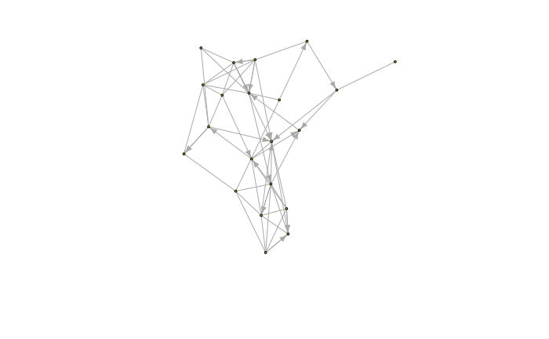

```r
set.seed(333)
plot(LaggedSpearGraph,vertex.size=2, vertex.label.cex = 0.75, edge.arrow.mode = E(LaggedSpearGraph)$arrow, vertex.label = NA, edge.arrow.size = .5)
```

Clearly, I’m not an igraph artist but you get the idea.

# SPARCC

As above but this time with sparcc

Sparcc doesn’t allow relative abundance data, it has to be counts. We can fake this with alrisa, by multiplying everything by 1000 and then rounding to the nearist

```r
spotWLagCounts <- round(spotWLag * 1000)
```

```r
tp0 <- proc.time()
lagSparcc <- sparcc(spotWLagCounts)
tp1 <- proc.time()
tp1 - tp0
```

```
   user  system elapsed
  0.908   0.000   0.906
```

Bootstrapping step, so we can have p values

```r
tp0 <- proc.time()
bootSparcc <- sparccboot(spotWLagCounts, R = 100)
tp1 <- proc.time()
tp1 - tp0
```

```
   user  system elapsed
113.725   0.194 113.974
```

Slow, of course. In real life you’d want to do at least 1000 permutations.

Calculate P values

```r
PSparcc <- pval.sparccboot(bootSparcc)
data.frame(PSparcc$cors, PSparcc$pvals)
```

| PSparcc.cors | PSparcc.pvals |
| --- | --- |
| 0.5544037636 | 0.00 |
| 0.2917925889 | 0.00 |
| 0.3945958043 | 0.00 |
| 0.0097467809 | 0.90 |
| 0.1439080966 | 0.20 |
| 0.2694324048 | 0.00 |
| -0.0642756610 | 0.36 |
| 0.0618355398 | 0.70 |
| 0.0370653479 | 0.72 |
| 0.3065749751 | 0.00 |

[output cut: 851 more lines]

Extract from the triangular matrix I ought to make a function to do this automatically.

```r
clean_Psparcc <- function(ps_mtx, cNames){

  cors <-ps_mtx$cors
  pvals <- ps_mtx$pvals

  nVars <- length(cNames)

  # Dump the values into a rectangular matrix
  # Empty matrix
  sparCCpcors <- diag(0.5, nrow = nVars, ncol = nVars)
  # Fill in upper triangle
  sparCCpcors[upper.tri(sparCCpcors, diag=FALSE)] <- cors
  # Fill in lower triangle
  sparCCpcors <- sparCCpcors + t(sparCCpcors)

  # As above, but for p values
  sparCCpval <- diag(0.5, nrow = nVars, ncol = nVars)
  sparCCpval[upper.tri(sparCCpval, diag=FALSE)] <- pvals
  sparCCpval <- sparCCpval + t(sparCCpval)

  rownames(sparCCpcors) <- cNames
  colnames(sparCCpcors) <- cNames
  rownames(sparCCpval) <- cNames
  colnames(sparCCpval) <- cNames

  return(list(cors = sparCCpcors, p = sparCCpval))
}

cleanSparccData <- clean_Psparcc(PSparcc, colnames(spotWLag))
```

```r
reshape_sparcc <- function(csparcc){
  sparCCpcors <- csparcc$cors
  sparCCpval <- csparcc$p

reordered_all_sparcc <- reorder_cor_and_p(sparCCpcors, sparCCpval)
reordered_sparccCor <- reordered_all_sparcc$r
reordered_sparccP<- reordered_all_sparcc$p


sparccCor_processed <- reordered_sparccCor  %>% get_upper_tri() %>% reshape2::melt() %>% na.omit() %>% rename(cor = value)
sparccP_processed <- reordered_sparccP  %>% get_upper_tri() %>% reshape2::melt() %>% na.omit() %>% rename(p = value)

# join the two data frames

SparccP <- left_join(sparccCor_processed, sparccP_processed, by = c("Var1", "Var2")) #%>%
  # # remove self correlations
  # filter(Var1 != Var2) %>%
  # calculate the false discovery rate to adjust for multiple p values, not yet
  #mutate(fdr = p.adjust(p, method = "BH"))
SparccP
}

longLaggedSparccData <- reshape_sparcc(cleanSparccData)
head(longLaggedSparccData)
```

|  | Var1 | Var2 | cor | p |
| --- | --- | --- | --- | --- |
| 1 | lag1-ARISA_662 | lag1-ARISA_662 | 1.0000000 | 1 |
| 2 | lag1-ARISA_662 | lag1-ARISA_570.1 | 0.2777993 | 0 |
| 3 | lag1-ARISA_570.1 | lag1-ARISA_570.1 | 1.0000000 | 1 |
| 4 | lag1-ARISA_662 | lag1-ARISA_573.6 | 0.3657411 | 0 |
| 5 | lag1-ARISA_570.1 | lag1-ARISA_573.6 | 0.5710286 | 0 |
| 6 | lag1-ARISA_573.6 | lag1-ARISA_573.6 | 1.0000000 | 1 |

```r
wrangledLaggedSparccData <- wrangle_lagged(longLaggedSparccData, coef = "cor")
wrangledLaggedSparccData
```

| Var1 | Var2 | cor | p | delay | fdr | arrow |
| --- | --- | --- | --- | --- | --- | --- |
| ARISA_570.1 | ARISA_662 | 0.1382873962 | 0.18 | -1 | 0.34259819 | < |
| ARISA_573.6 | ARISA_662 | 0.1886245629 | 0.02 | -1 | 0.07118644 | < |
| ARISA_573.6 | ARISA_570.1 | 0.2493757563 | 0.00 | -1 | 0.00000000 | < |
| ARISA_662 | ARISA_570.1 | 0.2188899269 | 0.00 | 0 | 0.00000000 | - |
| ARISA_662 | ARISA_573.6 | 0.3067065296 | 0.00 | 0 | 0.00000000 | - |
| ARISA_570.1 | ARISA_573.6 | 0.5481518377 | 0.00 | 0 | 0.00000000 | - |
| ARISA_662 | ARISA_666.4 | -0.0633311560 | 0.58 | 0 | 0.71647059 | - |
| ARISA_570.1 | ARISA_666.4 | 0.1299530180 | 0.24 | 0 | 0.41652893 | - |
| ARISA_573.6 | ARISA_666.4 | 0.0896937657 | 0.50 | 0 | 0.64814815 | - |
| ARISA_662 | ARISA_686.9 | 0.1345077243 | 0.02 | 0 | 0.07118644 | - |

[output cut: 221 more lines]

```r
wrangledLaggedSparccData %>% pull(p)
```

```
  [1] 0.18 0.02 0.00 0.00 0.00 0.00 0.58 0.24 0.50 0.02 0.22 0.42 0.00 0.00 0.02 0.00 0.00 0.68 0.00 0.00 0.06 0.00
 [23] 0.00 0.06 0.64 0.74 0.16 0.10 0.22 0.60 0.08 0.10 0.00 0.06 0.00 0.00 0.00 0.06 0.08 0.28 0.00 0.28 0.02 0.00
 [45] 0.06 0.00 0.44 0.46 0.06 0.00 0.02 0.24 0.68 0.38 0.12 0.32 0.02 0.86 0.22 0.54 0.32 0.10 0.12 0.52 0.06 0.18
 [67] 0.18 0.22 0.44 0.00 0.74 0.06 0.46 0.90 0.28 0.02 0.00 0.74 0.16 0.06 0.92 0.70 0.88 0.16 0.02 0.84 0.10 0.02
 [89] 0.46 0.56 0.08 0.00 0.20 0.02 0.16 0.62 0.28 0.70 0.50 0.60 0.40 0.30 0.82 0.56 0.28 0.34 0.54 0.16 0.54 0.60
[111] 0.28 0.66 0.52 0.56 0.70 0.92 0.50 0.38 0.00 0.80 0.48 0.44 0.26 0.00 0.72 0.14 0.56 0.80 0.10 0.86 0.42 0.12
[133] 0.04 0.08 0.04 0.04 0.86 0.90 0.36 0.10 0.38 0.40 0.14 0.00 0.00 0.00 0.34 0.12 0.20 0.70 0.26 0.08 0.00 0.00
[155] 0.04 0.00 0.00 0.58 0.44 0.06 0.06 0.24 0.68 0.04 0.62 0.82 0.00 1.00 0.24 0.04 0.02 0.00 0.34 0.02 0.36 0.04
[177] 0.32 0.50 0.06 0.14 0.92 0.98 0.22 0.10 0.08 0.82 0.60 0.32 0.32 0.98 0.76 0.14 0.56 0.34 0.58 0.00 0.50 1.00
[199] 0.06 0.60 0.30 0.62 0.20 0.00 0.80 0.40 0.50 0.88 0.62 0.02 0.06 0.00 0.44 0.98 0.88 0.00 0.60 0.10 0.86 0.00
[221] 0.00 0.00 0.00 0.02 0.00 0.00 0.02 0.00 0.04 1.00 0.20
```

```r
LaggedSparccGraph <- graph_from_data_frame(wrangledLaggedSparccData %>% filter(fdr < 0.05))
LaggedSparccGraph
```

```
IGRAPH d2dbbca DN-- 21 45 --
+ attr: name (v/c), cor (e/n), p (e/n), delay (e/n), fdr (e/n), arrow (e/c)
+ edges from d2dbbca (vertex names):
 [1] ARISA_573.6->ARISA_570.1 ARISA_662  ->ARISA_570.1 ARISA_662  ->ARISA_573.6 ARISA_570.1->ARISA_573.6
 [5] ARISA_666.4->ARISA_686.9 ARISA_570.1->ARISA_435.5 ARISA_666.4->ARISA_435.5 ARISA_686.9->ARISA_435.5
 [9] ARISA_570.1->ARISA_538.9 ARISA_573.6->ARISA_538.9 ARISA_686.9->ARISA_538.9 ARISA_435.5->ARISA_538.9
[13] ARISA_573.6->ARISA_594.1 ARISA_570.1->ARISA_561.8 ARISA_573.6->ARISA_561.8 ARISA_435.5->ARISA_561.8
[17] ARISA_594.1->ARISA_561.8 ARISA_435.5->ARISA_594.1 ARISA_561.8->ARISA_594.1 ARISA_435.5->ARISA_689.8
[21] ARISA_686.9->ARISA_682.4 ARISA_670.5->ARISA_682.4 ARISA_573.6->ARISA_419.5 ARISA_828.8->ARISA_831.8
[25] ARISA_435.5->ARISA_421.5 ARISA_828.8->ARISA_402.4 ARISA_831.8->ARISA_402.4 ARISA_421.5->ARISA_402.4
[29] ARISA_670.5->ARISA_419.5 ARISA_828.8->ARISA_419.5 ARISA_421.5->ARISA_419.5 ARISA_402.4->ARISA_419.5
+ ... omitted several edges
```

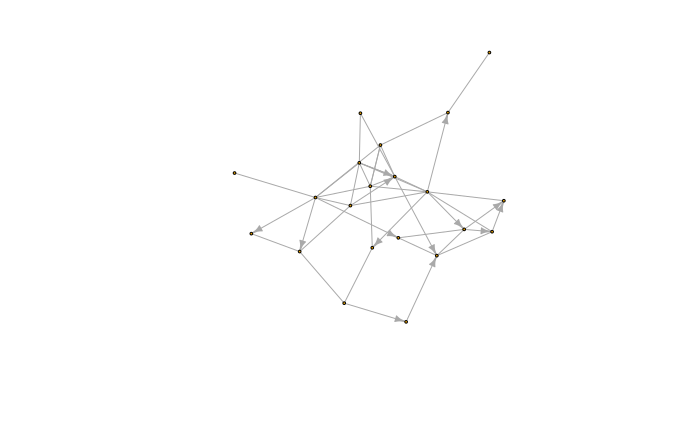

```r
set.seed(333)
plot(LaggedSparccGraph,vertex.size=2, vertex.label.cex = 0.75, edge.arrow.mode = E(LaggedSpearGraph)$arrow, vertex.label = NA, edge.arrow.size = .5)
```

As you can see, this network looks more like mola-mola as drawn by Picasso than the spearman one, but otherwise pretty qualitatively similar.